# analysis

```python
from pathlib import Path

import scanpy as sc
import pandas as pd
import numpy as np

import matplotlib.pyplot as plt

from plotnine import (
    ggplot,
    aes,
    geom_col,
    coord_flip,
    labs,
    theme_bw,
    theme,
    element_text
)
```

## Data path

```python
#check current working directory
print(Path.cwd())

#set data path
data_path = Path("../data/raw/hvca_ec.h5ad")
print(data_path)
```

```
/Users/FV/Documents/Personal/work/CV/portfolio/hvca-endothelial-reanalysis/analysis
../data/raw/hvca_ec.h5ad
```

## Loading data

I start from the processed endothelial-cell object. I am not reprocessing the raw data here. For this project I only want to inspect the published annotations, metadata, and marker patterns.

```python
#checking if data file exists
data = sc.read_h5ad(data_path)
print(data)

#checking data dimensions
print("Cells:", data.n_obs)
print("Genes:", data.n_vars)
```

```
AnnData object with n_obs × n_vars = 34433 × 30021
    obs: 'donor', 'kit', 'study', 'organ_uni', 'n_genes_by_counts', 'log1p_n_genes_by_counts', 'total_counts', 'log1p_total_counts', 'total_counts_mt', 'log1p_total_counts_mt', 'pct_counts_mt', 'total_counts_rb', 'pct_counts_rb', 'sex', 'scrublet_score', 'doublet_bh_pval', 'broad_celltype', 'art_ven…
    var: 'mt', 'rb', 'highly_variable', 'ENSG_id-1'
    uns: 'ann_ec_states_colors', 'art_ven_colors', 'cap_colors'
    obsm: 'X_scVI', 'X_umap', '_scvi_extra_categorical_covs', '_scvi_extra_continuous_covs'
    layers: 'counts'
    obsp: 'connectivities', 'distances'
Cells: 34433
Genes: 30021
```

## Metadata and annotation columns

The object is already filtered to endothelial cells, so I use the existing annotations provided with the dataset.

For this analysis, I use:

- `organ_uni` as the organ/tissue label
- `art_ven` as the broad endothelial compartment label
- `cap` as the capillary-related label
- `ann_ec_states` as the endothelial-state annotation
- `donor`, `sample_id`, `study`, and `dataset` to keep track of where cells come from

```python
#inspecting metadata
data.obs.head()
```

|  | donor | kit | study | organ_uni | n_genes_by_counts | log1p_n_genes_by_counts | total_counts | log1p_total_counts | total_counts_mt | log1p_total_counts_mt | ... | scrublet_score | doublet_bh_pval | broad_celltype | art_ven | cap | ann_ec_states | sample_id | age_groups | dataset | dataset_group |
| --- | --- | --- | --- | --- | --- | --- | --- | --- | --- | --- | --- | --- | --- | --- | --- | --- | --- | --- | --- | --- | --- |
| ctrl12_ATTCCTACAGGGCTTC-0 | CTRL12 | 10x3prime_v3 | Winkler_et_al_2022 | brain | 5780 | 8.662332 | 21583.0 | 9.979708 | 451.0 | 6.113682 | ... | NaN | NaN | NaN | cap_ec | blood_brain_barrier_ec | blood_brain_barrier_ec | CTRL12 | nan | Winkler_2022 | Nowakowski_lab |
| ctrl12_TTCAGGAGTTGGGTTT-0 | CTRL12 | 10x3prime_v3 | Winkler_et_al_2022 | brain | 6237 | 8.738415 | 23722.0 | 10.074200 | 698.0 | 6.549651 | ... | NaN | NaN | NaN | cap_ec | blood_brain_barrier_ec | blood_brain_barrier_ec | CTRL12 | nan | Winkler_2022 | Nowakowski_lab |
| ctrl12_CTAGACAGTTGCTAGT-0 | CTRL12 | 10x3prime_v3 | Winkler_et_al_2022 | brain | 5178 | 8.552367 | 16543.0 | 9.713779 | 168.0 | 5.129899 | ... | NaN | NaN | NaN | cap_ec | blood_brain_barrier_ec | blood_brain_barrier_ec | CTRL12 | nan | Winkler_2022 | Nowakowski_lab |
| ctrl12_GTTGTAGAGGTTCATC-0 | CTRL12 | 10x3prime_v3 | Winkler_et_al_2022 | brain | 5796 | 8.665096 | 18207.0 | 9.809616 | 180.0 | 5.198497 | ... | NaN | NaN | NaN | cap_ec | blood_brain_barrier_ec | blood_brain_barrier_ec | CTRL12 | nan | Winkler_2022 | Nowakowski_lab |
| ctrl12_GAAACCTCATCCCACT-0 | CTRL12 | 10x3prime_v3 | Winkler_et_al_2022 | brain | 4860 | 8.488999 | 15974.0 | 9.678780 | 267.0 | 5.590987 | ... | NaN | NaN | NaN | cap_ec | blood_brain_barrier_ec | blood_brain_barrier_ec | CTRL12 | nan | Winkler_2022 | Nowakowski_lab |

5 rows × 24 columns

```python
#inspecting colnames
list(data.obs.columns)
```

```
['donor',
 'kit',
 'study',
 'organ_uni',
 'n_genes_by_counts',
 'log1p_n_genes_by_counts',
 'total_counts',
 'log1p_total_counts',
 'total_counts_mt',
 'log1p_total_counts_mt',
 'pct_counts_mt',
 'total_counts_rb',
 'pct_counts_rb',
 'sex',
 'scrublet_score',
 'doublet_bh_pval',
 'broad_celltype',
 'art_ven',
 'cap',
 'ann_ec_states',
 'sample_id',
 'age_groups',
 'dataset',
 'dataset_group']
```

```python
#inspecting obsm keys
list(data.obsm.keys())
```

```
['X_scVI',
 'X_umap',
 '_scvi_extra_categorical_covs',
 '_scvi_extra_continuous_covs']
```

```python
#defining metadata columns used for analysis
organ_col = "organ_uni"
broad_state_col = "art_ven"
cap_col = "cap"
state_col = "ann_ec_states"

donor_col = "donor"
sample_col = "sample_id"
study_col = "study"
dataset_col = "dataset"
kit_col = "kit"
sex_col = "sex"
age_col = "age_groups"

key_cols = [
    organ_col,
    broad_state_col,
    cap_col,
    state_col,
    donor_col,
    sample_col,
    study_col,
    dataset_col,
    kit_col,
    sex_col,
    age_col,
]
```

### Missing metadata summary

Before using these columns, I check how much missing information they contain.

```python
missing_summary = (
    data.obs[key_cols]
    .isna()
    .sum()
    .to_frame("n_missing"))

missing_summary["pct_missing"] = (missing_summary["n_missing"] / data.n_obs * 100).round(2)

missing_summary
```

|  | n_missing | pct_missing |
| --- | --- | --- |
| organ_uni | 0 | 0.00 |
| art_ven | 0 | 0.00 |
| cap | 0 | 0.00 |
| ann_ec_states | 0 | 0.00 |
| donor | 0 | 0.00 |
| sample_id | 0 | 0.00 |
| study | 0 | 0.00 |
| dataset | 0 | 0.00 |
| kit | 0 | 0.00 |
| sex | 952 | 2.76 |
| age_groups | 0 | 0.00 |

No missing values besides sex. Nonetheless, for this project, it doesn't impair the analyses

## Cell counts by organ and annotation

I first count how many cells are present for each organ and annotation label. These counts describe the dataset, not the real abundance of endothelial cells in the body.

```python
cell_counts_by_organ = (
    data.obs[organ_col]
    .value_counts(dropna=False)
    .rename_axis("organ")
    .reset_index(name="n_cells"))

cell_counts_by_broad_state = (
    data.obs[broad_state_col]
    .value_counts(dropna=False)
    .rename_axis("broad_state")
    .reset_index(name="n_cells"))

cell_counts_by_cap = (
    data.obs[cap_col]
    .value_counts(dropna=False)
    .rename_axis("cap_label")
    .reset_index(name="n_cells"))

cell_counts_by_state = (
    data.obs[state_col]
    .value_counts(dropna=False)
    .rename_axis("ec_state")
    .reset_index(name="n_cells"))

print(cell_counts_by_organ.head(5))
print(cell_counts_by_broad_state.head(5))
print(cell_counts_by_cap.head(5))
print(cell_counts_by_state.head(5))
```

```
        organ  n_cells
0       heart     6283
1        lung     5647
2      muscle     3936
3  lymph_node     2653
4       liver     2522
  broad_state  n_cells
0      cap_ec    23128
1    ven_ec_2     2522
2    art_ec_2     2215
3    ven_ec_1     2137
4  pul_ven_ec     1286
    cap_label  n_cells
0  myo_cap_ec     7842
1      ven_ec     6088
2      art_ec     5153
3      cap_ec     3334
4  pul_cap_ec     2277
     ec_state  n_cells
0  myo_cap_ec     7842
1      cap_ec     3334
2    ven_ec_2     2522
3  pul_cap_ec     2277
4    art_ec_2     2215
```

### Simple count plots

The dataset is not evenly distributed across organs or annotation labels. This matters because large groups can dominate later visualizations, especially UMAPs and summary plots.

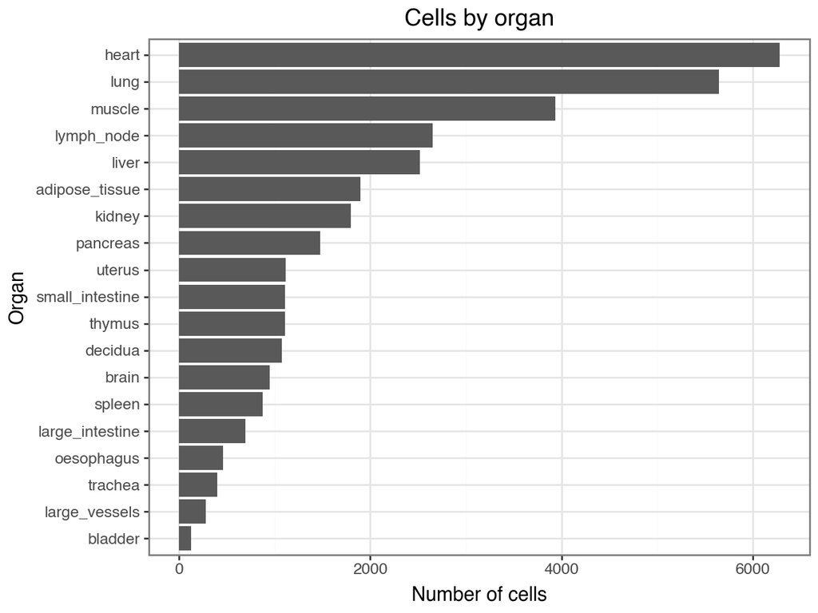

```python
#plotting cell counts by organ
cell_counts_by_organ["organ"] = pd.Categorical(
    cell_counts_by_organ["organ"],
    categories=cell_counts_by_organ.sort_values("n_cells")["organ"],
    ordered=True)

(ggplot(cell_counts_by_organ, aes(x="reorder(organ, n_cells)", y="n_cells"))
    + geom_col()
    + coord_flip()
    + labs(
        x="Organ",
        y="Number of cells",
        title="Cells by organ"
    )
    + theme_bw())
```

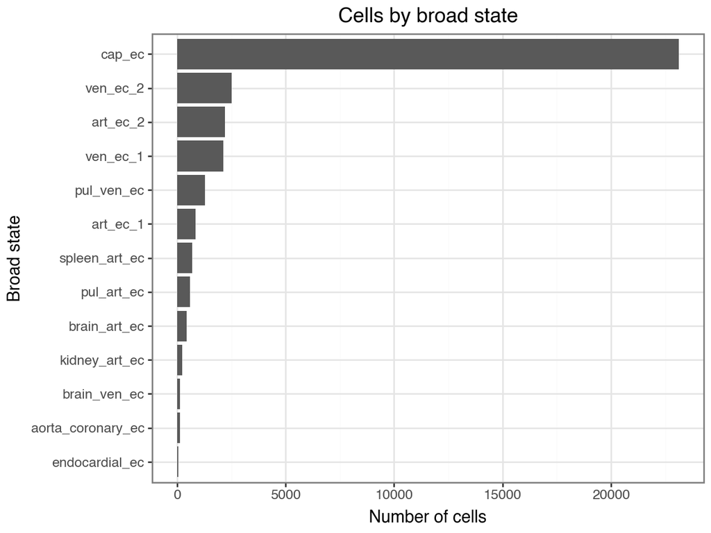

```python
#plotting cell counts by broad state
cell_counts_by_broad_state["broad_state"] = pd.Categorical(
    cell_counts_by_broad_state["broad_state"],
    categories=cell_counts_by_broad_state.sort_values("n_cells")["broad_state"],
    ordered=True)

(ggplot(cell_counts_by_broad_state, aes(x="reorder(broad_state, n_cells)", y="n_cells"))
    + geom_col()
    + coord_flip()
    + labs(
        x="Broad state",
        y="Number of cells",
        title="Cells by broad state"
    )
    + theme_bw())
```

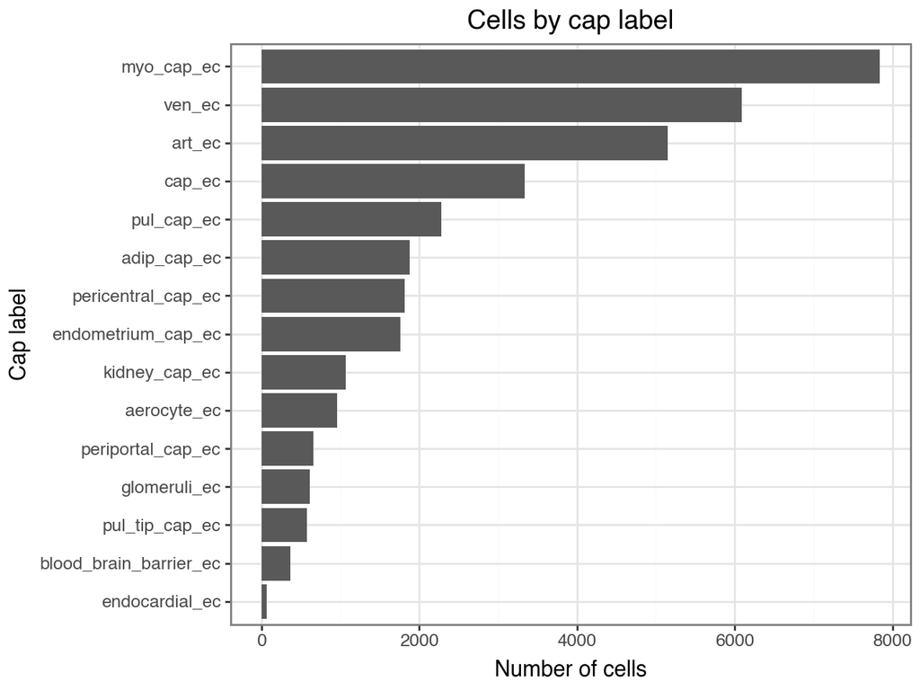

```python
#plotting cell counts by cap
cell_counts_by_cap["cap_label"] = pd.Categorical(
    cell_counts_by_cap["cap_label"],
    categories=cell_counts_by_cap.sort_values("n_cells")["cap_label"],
    ordered=True)

(ggplot(cell_counts_by_cap, aes(x="reorder(cap_label, n_cells)", y="n_cells"))
    + geom_col()
    + coord_flip()
    + labs(
        x="Cap label",
        y="Number of cells",
        title="Cells by cap label"
    )
    + theme_bw())
```

The dataset is not evenly distributed across organs or annotation labels. This matters because large groups can dominate later visualizations, especially UMAPs and summary plots.

## UMAP overview

The dataset already includes UMAP coordinates, so I use them to look at the existing annotations on the processed object.

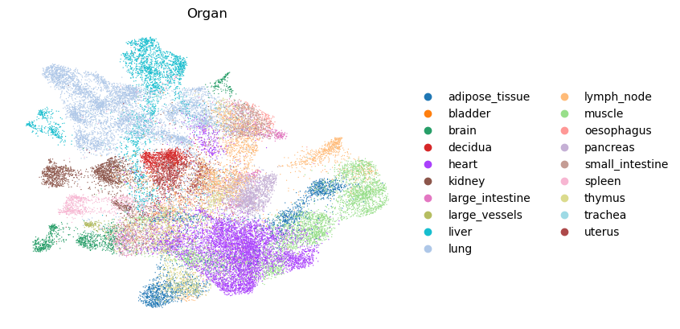

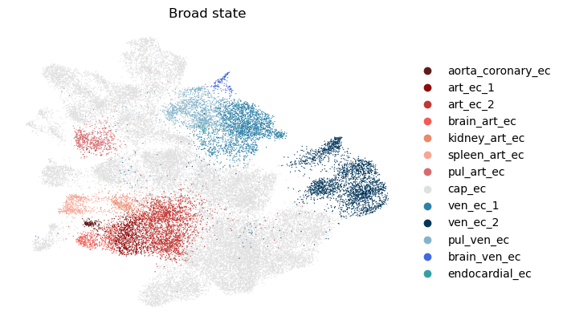

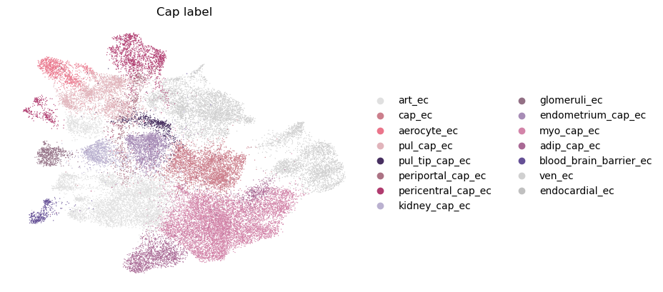

```python
#listing embeddings
list(data.obsm.keys())

#plotting umap colored by organ
sc.pl.umap(data,
    color=organ_col,
    frameon=False,
    title="Organ")

#plotting umap colored by broad state
sc.pl.umap(data,
        color=broad_state_col,
        frameon=False,
        title="Broad state")

#plotting umap colored by cap
sc.pl.umap(data,
        color=cap_col,
        frameon=False,
        title="Cap label")
```

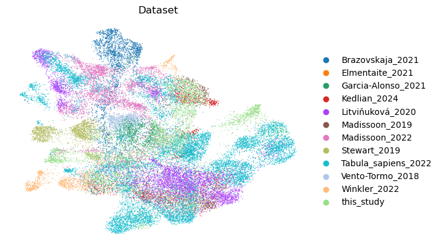

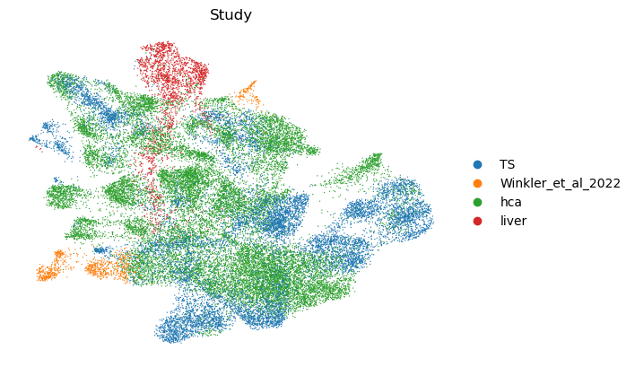

```python
#plot umap by dataset (batch effect)
sc.pl.umap(
    data,
    color=dataset_col,
    frameon=False,
    title="Dataset")

#plot umap by study (batch effect)
sc.pl.umap(
    data,
    color=study_col,
    frameon=False,
    title="Study"
)
```

These UMAPs are only a first visual check. I use them to see how organs, annotations, and source datasets are arranged in the processed object.

The dataset and study labels are mixed across much of the UMAP, although some regions are still enriched for specific sources. So I would not say the embedding is obviously dominated by dataset source, but I also cannot use a UMAP to rule out batch effects.

### Relationship between annotation columns

The dataset includes several endothelial annotation columns. I compare `cap` and `ann_ec_states` to see whether they represent different annotation levels or mostly the same labels.

```python
data.obs["ann_ec_states"].value_counts()
```

```
ann_ec_states
myo_cap_ec                7842
cap_ec                    3334
ven_ec_2                  2522
pul_cap_ec                2277
art_ec_2                  2215
ven_ec_1                  2137
adip_cap_ec               1879
pericentral_cap_ec        1809
endometrium_cap_ec        1755
pul_ven_ec                1286
kidney_cap_ec             1067
aerocyte_ec                952
art_ec_1                   858
spleen_art_ec              700
periportal_cap_ec          660
glomeruli_ec               609
pul_art_ec                 581
pul_tip_cap_ec             576
brain_art_ec               426
blood_brain_barrier_ec     368
kidney_art_ec              235
brain_ven_ec               143
aorta_coronary_ec          138
endocardial_ec              64
Name: count, dtype: int64
```

```python
data.obs["cap"].value_counts()
```

```
cap
myo_cap_ec                7842
ven_ec                    6088
art_ec                    5153
cap_ec                    3334
pul_cap_ec                2277
adip_cap_ec               1879
pericentral_cap_ec        1809
endometrium_cap_ec        1755
kidney_cap_ec             1067
aerocyte_ec                952
periportal_cap_ec          660
glomeruli_ec               609
pul_tip_cap_ec             576
blood_brain_barrier_ec     368
endocardial_ec              64
Name: count, dtype: int64
```

```python
pd.crosstab(data.obs["cap"], data.obs["ann_ec_states"])
```

| ann_ec_states cap | aorta_coronary_ec | art_ec_1 | art_ec_2 | brain_art_ec | kidney_art_ec | spleen_art_ec | pul_art_ec | ven_ec_1 | ven_ec_2 | pul_ven_ec | ... | pul_cap_ec | pul_tip_cap_ec | periportal_cap_ec | pericentral_cap_ec | kidney_cap_ec | glomeruli_ec | endometrium_cap_ec | myo_cap_ec | adip_cap_ec | blood_brain_barrier_ec |
| --- | --- | --- | --- | --- | --- | --- | --- | --- | --- | --- | --- | --- | --- | --- | --- | --- | --- | --- | --- | --- | --- |
| art_ec | 138 | 858 | 2215 | 426 | 235 | 700 | 581 | 0 | 0 | 0 | ... | 0 | 0 | 0 | 0 | 0 | 0 | 0 | 0 | 0 | 0 |
| cap_ec | 0 | 0 | 0 | 0 | 0 | 0 | 0 | 0 | 0 | 0 | ... | 0 | 0 | 0 | 0 | 0 | 0 | 0 | 0 | 0 | 0 |
| aerocyte_ec | 0 | 0 | 0 | 0 | 0 | 0 | 0 | 0 | 0 | 0 | ... | 0 | 0 | 0 | 0 | 0 | 0 | 0 | 0 | 0 | 0 |
| pul_cap_ec | 0 | 0 | 0 | 0 | 0 | 0 | 0 | 0 | 0 | 0 | ... | 2277 | 0 | 0 | 0 | 0 | 0 | 0 | 0 | 0 | 0 |
| pul_tip_cap_ec | 0 | 0 | 0 | 0 | 0 | 0 | 0 | 0 | 0 | 0 | ... | 0 | 576 | 0 | 0 | 0 | 0 | 0 | 0 | 0 | 0 |
| periportal_cap_ec | 0 | 0 | 0 | 0 | 0 | 0 | 0 | 0 | 0 | 0 | ... | 0 | 0 | 660 | 0 | 0 | 0 | 0 | 0 | 0 | 0 |
| pericentral_cap_ec | 0 | 0 | 0 | 0 | 0 | 0 | 0 | 0 | 0 | 0 | ... | 0 | 0 | 0 | 1809 | 0 | 0 | 0 | 0 | 0 | 0 |
| kidney_cap_ec | 0 | 0 | 0 | 0 | 0 | 0 | 0 | 0 | 0 | 0 | ... | 0 | 0 | 0 | 0 | 1067 | 0 | 0 | 0 | 0 | 0 |
| glomeruli_ec | 0 | 0 | 0 | 0 | 0 | 0 | 0 | 0 | 0 | 0 | ... | 0 | 0 | 0 | 0 | 0 | 609 | 0 | 0 | 0 | 0 |
| endometrium_cap_ec | 0 | 0 | 0 | 0 | 0 | 0 | 0 | 0 | 0 | 0 | ... | 0 | 0 | 0 | 0 | 0 | 0 | 1755 | 0 | 0 | 0 |
| myo_cap_ec | 0 | 0 | 0 | 0 | 0 | 0 | 0 | 0 | 0 | 0 | ... | 0 | 0 | 0 | 0 | 0 | 0 | 0 | 7842 | 0 | 0 |
| adip_cap_ec | 0 | 0 | 0 | 0 | 0 | 0 | 0 | 0 | 0 | 0 | ... | 0 | 0 | 0 | 0 | 0 | 0 | 0 | 0 | 1879 | 0 |
| blood_brain_barrier_ec | 0 | 0 | 0 | 0 | 0 | 0 | 0 | 0 | 0 | 0 | ... | 0 | 0 | 0 | 0 | 0 | 0 | 0 | 0 | 0 | 368 |
| ven_ec | 0 | 0 | 0 | 0 | 0 | 0 | 0 | 2137 | 2522 | 1286 | ... | 0 | 0 | 0 | 0 | 0 | 0 | 0 | 0 | 0 | 0 |
| endocardial_ec | 0 | 0 | 0 | 0 | 0 | 0 | 0 | 0 | 0 | 0 | ... | 0 | 0 | 0 | 0 | 0 | 0 | 0 | 0 | 0 | 0 |

15 rows × 24 columns

The `cap` and `ann_ec_states` columns are closely related. Many labels match directly. The main difference is that `cap` groups arterial and venous cells more broadly, while `ann_ec_states` keeps more detailed arterial and venous subtypes.

For the next plots, I use `cap` because it is detailed enough to show tissue-related endothelial labels, but not as fragmented as `ann_ec_states`.

## Marker checks

I next check a small set of known vascular markers across the existing labels. I am not re-annotating the cells here; I just want to see whether the labels behave as expected.

```python
#building marker dict
marker_genes = {
    "pan_endothelial": ["PECAM1", "CDH5", "VWF", "KDR"],
    "arterial": ["GJA5", "SOX17", "EFNB2", "DLL4"],
    "venous": ["NR2F2", "ACKR1"],
    "capillary": ["RGCC", "CA4", "EMCN", "PLVAP"],
    "lung_capillary": ["EDNRB", "SOSTDC1"],
    "blood_brain_barrier": ["CLDN5", "SLC2A1", "ABCB1"],
    "liver_zonation": ["RAMP3", "CLEC4G"],
    "kidney_glomerular": ["EHD3", "PLVAP"]}

#checking which genes are present
all_markers = [gene
    for genes in marker_genes.values()
    for gene in genes]

marker_presence = pd.DataFrame({"gene": all_markers,
    "present_in_object": [gene in data.var_names for gene in all_markers]})

print(marker_presence)

#keep present genes
present_markers = marker_presence.loc[marker_presence["present_in_object"],
    "gene"].tolist()

print(present_markers)
```

```
       gene  present_in_object
0    PECAM1               True
1      CDH5               True
2       VWF               True
3       KDR               True
4      GJA5               True
5     SOX17               True
6     EFNB2               True
7      DLL4               True
8     NR2F2               True
9     ACKR1               True
10     RGCC               True
11      CA4               True
12     EMCN               True
13    PLVAP               True
14    EDNRB               True
15  SOSTDC1               True
16    CLDN5               True
17   SLC2A1               True
18    ABCB1               True
19    RAMP3               True
20   CLEC4G               True
21     EHD3               True
22    PLVAP               True
['PECAM1', 'CDH5', 'VWF', 'KDR', 'GJA5', 'SOX17', 'EFNB2', 'DLL4', 'NR2F2', 'ACKR1', 'RGCC', 'CA4', 'EMCN', 'PLVAP', 'EDNRB', 'SOSTDC1', 'CLDN5', 'SLC2A1', 'ABCB1', 'RAMP3', 'CLEC4G', 'EHD3', 'PLVAP']
```

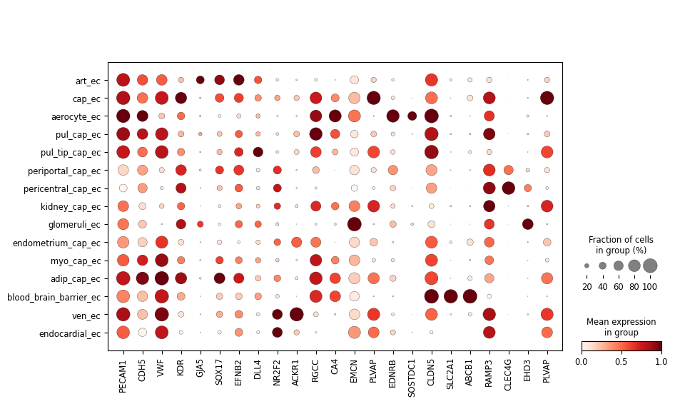

```python
#plotting
sc.pl.dotplot(
    data,
    var_names=present_markers,
    groupby=cap_col,
    standard_scale="var",
    dendrogram=False)
```

The marker plot mostly behaves as expected. Pan-endothelial markers are present across most groups, arterial markers are strongest in `art_ec`, venous markers are strongest in `ven_ec`, and blood-brain-barrier markers are strongest in `blood_brain_barrier_ec`.

I use this as a marker check, not as a new annotation.

## Organ and annotation overlap

Some endothelial labels are broad, while others look tissue-specific, so I next check how labels and organs overlap.

```python
#calculating percentage of cells in each cap label by organ
organ_cap_counts = pd.crosstab(
    data.obs[organ_col],
    data.obs[cap_col]
)

organ_cap_pct = organ_cap_counts.div(
    organ_cap_counts.sum(axis=1),
    axis=0
) * 100

organ_cap_pct.round(1)
```

| cap organ_uni | art_ec | cap_ec | aerocyte_ec | pul_cap_ec | pul_tip_cap_ec | periportal_cap_ec | pericentral_cap_ec | kidney_cap_ec | glomeruli_ec | endometrium_cap_ec | myo_cap_ec | adip_cap_ec | blood_brain_barrier_ec | ven_ec | endocardial_ec |
| --- | --- | --- | --- | --- | --- | --- | --- | --- | --- | --- | --- | --- | --- | --- | --- |
| adipose_tissue | 8.4 | 0.1 | 0.0 | 0.0 | 0.0 | 0.0 | 0.0 | 0.0 | 0.0 | 0.0 | 2.5 | 64.8 | 0.0 | 24.2 | 0.0 |
| bladder | 22.3 | 34.6 | 0.8 | 3.1 | 2.3 | 0.0 | 0.0 | 0.8 | 0.0 | 5.4 | 8.5 | 0.8 | 0.0 | 21.5 | 0.0 |
| brain | 46.1 | 0.0 | 0.0 | 0.0 | 0.0 | 0.0 | 0.0 | 0.0 | 0.0 | 0.1 | 0.1 | 0.0 | 38.7 | 15.0 | 0.0 |
| decidua | 0.6 | 0.2 | 0.0 | 0.1 | 0.2 | 0.1 | 0.3 | 0.0 | 0.0 | 98.1 | 0.1 | 0.0 | 0.0 | 0.4 | 0.0 |
| heart | 9.6 | 0.3 | 0.0 | 0.2 | 0.2 | 0.0 | 0.0 | 0.2 | 0.0 | 0.0 | 84.7 | 0.0 | 0.0 | 3.9 | 0.8 |
| kidney | 15.8 | 0.8 | 0.0 | 0.1 | 0.1 | 0.1 | 0.2 | 48.3 | 32.5 | 0.3 | 0.5 | 0.1 | 0.0 | 1.2 | 0.0 |
| large_intestine | 27.2 | 22.2 | 0.1 | 0.1 | 0.0 | 0.0 | 0.0 | 1.0 | 0.0 | 0.1 | 3.9 | 0.6 | 0.0 | 44.7 | 0.0 |
| large_vessels | 76.1 | 9.2 | 0.0 | 0.0 | 0.4 | 0.4 | 0.0 | 5.3 | 0.4 | 0.0 | 3.2 | 3.2 | 0.0 | 2.1 | 0.0 |
| liver | 2.4 | 0.3 | 0.0 | 0.4 | 0.0 | 24.0 | 70.7 | 1.1 | 0.2 | 0.0 | 0.0 | 0.0 | 0.0 | 0.6 | 0.2 |
| lung | 10.8 | 1.5 | 16.8 | 39.1 | 9.4 | 0.3 | 0.1 | 0.3 | 0.2 | 0.4 | 0.3 | 0.0 | 0.0 | 20.8 | 0.1 |
| lymph_node | 13.9 | 31.5 | 0.0 | 0.0 | 0.5 | 0.0 | 0.0 | 2.2 | 0.0 | 0.2 | 1.3 | 4.9 | 0.0 | 45.5 | 0.0 |
| muscle | 7.5 | 0.1 | 0.0 | 0.0 | 0.1 | 0.0 | 0.0 | 0.0 | 0.0 | 0.0 | 56.6 | 0.8 | 0.0 | 34.8 | 0.0 |
| oesophagus | 30.4 | 12.9 | 0.0 | 0.0 | 0.0 | 0.0 | 0.0 | 2.4 | 0.0 | 0.4 | 3.9 | 0.0 | 0.0 | 49.4 | 0.6 |
| pancreas | 2.7 | 95.2 | 0.1 | 0.1 | 0.0 | 0.0 | 0.0 | 0.4 | 0.0 | 0.0 | 0.3 | 0.0 | 0.0 | 1.2 | 0.0 |
| small_intestine | 34.2 | 6.7 | 0.0 | 0.0 | 0.0 | 0.0 | 0.0 | 0.3 | 0.0 | 0.4 | 1.2 | 0.3 | 0.0 | 57.0 | 0.0 |
| spleen | 87.9 | 2.5 | 0.1 | 1.1 | 0.2 | 3.7 | 0.9 | 1.4 | 1.1 | 0.2 | 0.2 | 0.0 | 0.0 | 0.6 | 0.0 |
| thymus | 26.4 | 15.5 | 0.0 | 0.6 | 0.1 | 0.0 | 0.1 | 2.1 | 0.0 | 0.0 | 2.3 | 41.5 | 0.0 | 11.4 | 0.0 |
| trachea | 36.0 | 24.0 | 0.0 | 4.5 | 1.0 | 0.0 | 0.0 | 1.0 | 0.0 | 0.2 | 15.2 | 1.0 | 0.0 | 17.0 | 0.0 |
| uterus | 11.0 | 27.4 | 0.0 | 0.1 | 0.6 | 0.1 | 0.0 | 0.3 | 0.0 | 57.7 | 0.7 | 0.0 | 0.0 | 2.1 | 0.0 |

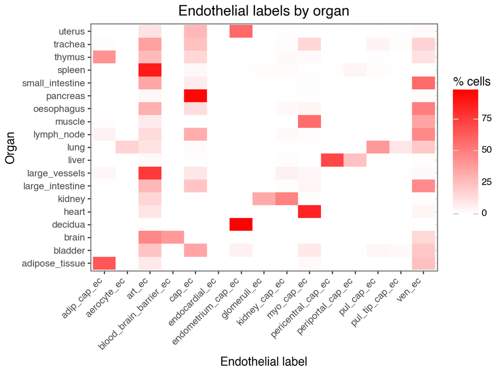

```python
#plotting results
from plotnine import geom_tile, scale_fill_gradient, element_text

organ_cap_long = (organ_cap_pct
    .reset_index()
    .melt(
        id_vars=organ_col,
        var_name="cap_label",
        value_name="pct_cells"
    ))

(ggplot(
        organ_cap_long,
        aes(x="cap_label", y=organ_col, fill="pct_cells")
    )
    + geom_tile()
    + scale_fill_gradient(low="white", high="red")
    + labs(
        x="Endothelial label",
        y="Organ",
        fill="% cells",
        title="Endothelial labels by organ"
    )
    + theme_bw()
    + theme(
        axis_text_x=element_text(rotation=45, ha="right")
    ))
```

The heatmap separates broad labels from more tissue-associated labels. `art_ec`, `ven_ec`, and `cap_ec` appear across several organs, while labels such as `blood_brain_barrier_ec`, `glomeruli_ec`, `aerocyte_ec`, and liver capillary labels are mostly tied to specific organs.

This should not be read as real endothelial abundance across organs. It only describes what is present in this processed object.

## Clustering sensitivity check

Single-cell clusters are not fixed objects. Here I run a small Leiden clustering check using the stored scVI embedding and vary a few basic parameters.

```python
#checking shape of embeddings
print(data.obsm["X_scVI"].shape)
print(data.obsm["X_umap"].shape)
```

```
(34433, 10)
(34433, 2)
```

```python
#clustering with leiden algorithm
sc.pp.neighbors(data, use_rep="X_scVI", n_neighbors=15)

sc.tl.leiden( data,
    resolution=0.5,
    key_added="leiden_r05_n15")

data.obs["leiden_r05_n15"].value_counts().sort_index()
```

```
leiden_r05_n15
0     6881
1     3707
2     3693
3     3024
4     2912
5     2002
6     1985
7     1903
8     1885
9     1779
10    1422
11    1051
12     705
13     537
14     513
15     434
Name: count, dtype: int64
```

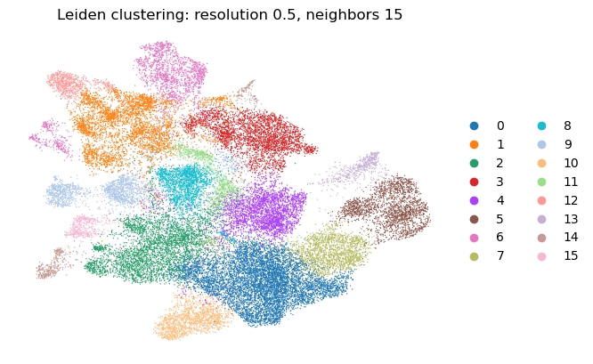

```python
#plotting clustering res
sc.pl.umap(data,
    color="leiden_r05_n15",
    frameon=False,
    title="Leiden clustering: resolution 0.5, neighbors 15")
```

```python
#calculating percentage of cells in each cap label by leiden cluster
leiden_cap_counts = pd.crosstab(
    data.obs["leiden_r05_n15"],
    data.obs[cap_col]
)

leiden_cap_pct = leiden_cap_counts.div(
    leiden_cap_counts.sum(axis=1),
    axis=0
) * 100

leiden_cap_pct.round(1)
```

| cap leiden_r05_n15 | art_ec | cap_ec | aerocyte_ec | pul_cap_ec | pul_tip_cap_ec | periportal_cap_ec | pericentral_cap_ec | kidney_cap_ec | glomeruli_ec | endometrium_cap_ec | myo_cap_ec | adip_cap_ec | blood_brain_barrier_ec | ven_ec | endocardial_ec |
| --- | --- | --- | --- | --- | --- | --- | --- | --- | --- | --- | --- | --- | --- | --- | --- |
| 0 | 8.3 | 0.6 | 0.1 | 0.1 | 0.1 | 0.0 | 0.0 | 0.1 | 0.0 | 0.1 | 89.2 | 1.0 | 0.0 | 0.4 | 0.0 |
| 1 | 15.3 | 0.3 | 7.1 | 58.9 | 2.3 | 7.8 | 0.5 | 0.1 | 0.0 | 0.1 | 0.1 | 0.0 | 0.0 | 7.3 | 0.0 |
| 2 | 90.0 | 2.6 | 0.0 | 0.1 | 0.1 | 4.8 | 0.2 | 0.3 | 0.1 | 0.5 | 1.0 | 0.1 | 0.1 | 0.3 | 0.0 |
| 3 | 0.2 | 0.4 | 0.0 | 0.3 | 0.0 | 0.1 | 0.3 | 0.4 | 0.0 | 0.4 | 0.1 | 0.0 | 0.0 | 95.8 | 2.0 |
| 4 | 2.2 | 88.1 | 0.0 | 0.4 | 0.6 | 0.5 | 0.1 | 1.8 | 0.0 | 0.2 | 2.9 | 1.7 | 0.0 | 1.5 | 0.0 |
| 5 | 0.0 | 0.1 | 0.0 | 0.0 | 0.0 | 0.0 | 0.0 | 0.0 | 0.0 | 0.0 | 1.4 | 0.2 | 0.0 | 98.2 | 0.0 |
| 6 | 0.8 | 0.1 | 0.1 | 0.6 | 0.2 | 7.4 | 87.8 | 2.3 | 0.0 | 0.3 | 0.1 | 0.1 | 0.0 | 0.5 | 0.0 |
| 7 | 4.8 | 0.1 | 0.1 | 0.2 | 1.1 | 0.0 | 0.0 | 0.1 | 0.0 | 0.0 | 73.5 | 19.4 | 0.0 | 0.8 | 0.0 |
| 8 | 1.9 | 0.6 | 0.1 | 0.4 | 0.3 | 0.3 | 0.3 | 0.2 | 0.0 | 89.9 | 5.0 | 0.0 | 0.0 | 1.1 | 0.1 |
| 9 | 0.7 | 0.9 | 0.0 | 0.7 | 0.1 | 1.1 | 1.2 | 51.3 | 33.4 | 0.1 | 0.7 | 0.1 | 0.1 | 9.4 | 0.1 |
| 10 | 1.0 | 0.5 | 0.0 | 0.1 | 0.1 | 0.0 | 0.0 | 0.4 | 0.0 | 0.0 | 1.6 | 96.2 | 0.0 | 0.1 | 0.0 |
| 11 | 1.4 | 51.1 | 0.0 | 1.0 | 40.5 | 0.2 | 0.1 | 1.1 | 0.0 | 1.1 | 1.7 | 0.6 | 0.0 | 1.0 | 0.0 |
| 12 | 0.3 | 0.0 | 95.9 | 1.8 | 0.3 | 0.0 | 0.0 | 0.0 | 1.6 | 0.0 | 0.0 | 0.0 | 0.0 | 0.1 | 0.0 |
| 13 | 0.0 | 5.4 | 0.0 | 0.2 | 0.2 | 0.0 | 0.0 | 0.0 | 0.0 | 0.0 | 0.0 | 0.0 | 0.0 | 94.2 | 0.0 |
| 14 | 1.6 | 0.0 | 0.0 | 0.0 | 0.0 | 0.0 | 0.0 | 0.2 | 0.0 | 0.2 | 0.2 | 0.2 | 71.0 | 26.7 | 0.0 |
| 15 | 99.1 | 0.5 | 0.0 | 0.0 | 0.0 | 0.5 | 0.0 | 0.0 | 0.0 | 0.0 | 0.0 | 0.0 | 0.0 | 0.0 | 0.0 |

```python
#summary table
dominant_cap_per_leiden = (leiden_cap_pct
    .idxmax(axis=1)
    .to_frame("dominant_cap_label"))

dominant_cap_per_leiden["dominant_pct"] = (leiden_cap_pct
    .max(axis=1)
    .round(1))

dominant_cap_per_leiden["cluster_size"] = (data.obs["leiden_r05_n15"]
    .value_counts()
    .sort_index()
    .values)

dominant_cap_per_leiden
```

| leiden_r05_n15 | dominant_cap_label | dominant_pct | cluster_size |
| --- | --- | --- | --- |
| 0 | myo_cap_ec | 89.2 | 6881 |
| 1 | pul_cap_ec | 58.9 | 3707 |
| 2 | art_ec | 90.0 | 3693 |
| 3 | ven_ec | 95.8 | 3024 |
| 4 | cap_ec | 88.1 | 2912 |
| 5 | ven_ec | 98.2 | 2002 |
| 6 | pericentral_cap_ec | 87.8 | 1985 |
| 7 | myo_cap_ec | 73.5 | 1903 |
| 8 | endometrium_cap_ec | 89.9 | 1885 |
| 9 | kidney_cap_ec | 51.3 | 1779 |
| 10 | adip_cap_ec | 96.2 | 1422 |
| 11 | cap_ec | 51.1 | 1051 |
| 12 | aerocyte_ec | 95.9 | 705 |
| 13 | ven_ec | 94.2 | 537 |
| 14 | blood_brain_barrier_ec | 71.0 | 513 |
| 15 | art_ec | 99.1 | 434 |

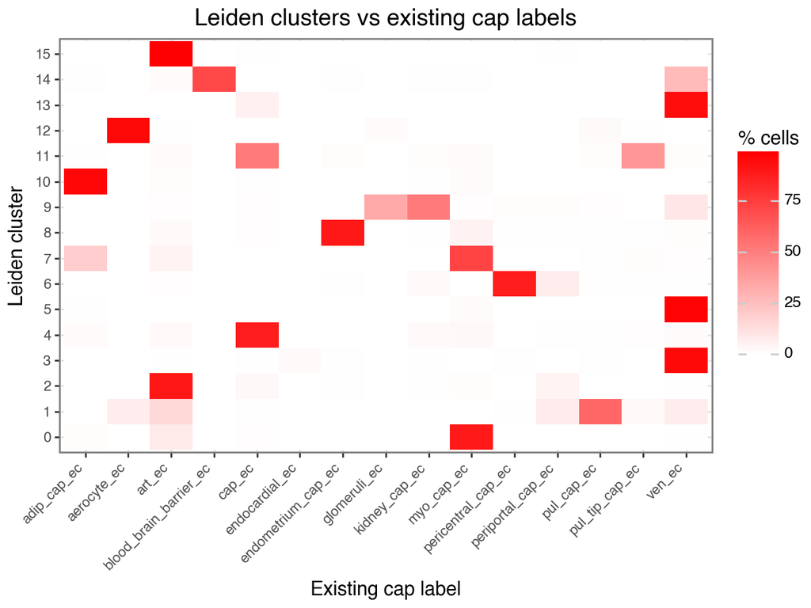

```python
#visual summary
leiden_cap_long = (leiden_cap_pct
    .reset_index()
    .melt(
        id_vars="leiden_r05_n15",
        var_name="cap_label",
        value_name="pct_cells"
    ))

(ggplot(
        leiden_cap_long,
        aes(x="cap_label", y="leiden_r05_n15", fill="pct_cells")
    )
    + geom_tile()
    + scale_fill_gradient(low="white", high="red")
    + labs(
        x="Existing cap label",
        y="Leiden cluster",
        fill="% cells",
        title="Leiden clusters vs existing cap labels"
    )
    + theme_bw()
    + theme(
        axis_text_x=element_text(rotation=45, ha="right", size=8),
        axis_text_y=element_text(size=8)
    ))
```

As expected, higher Leiden resolution gives more clusters. The match to the existing `cap` labels is moderate, not perfect.

This is enough for the point I wanted to check: clustering recovers part of the annotation structure, but the exact clusters depend on the parameters. I keep the published labels as the reference.

```python
from sklearn.metrics import adjusted_rand_score, normalized_mutual_info_score

sensitivity_results = []

for n_neighbors in [15, 30]:
    sc.pp.neighbors(
        data,
        use_rep="X_scVI",
        n_neighbors=n_neighbors,
        key_added=f"neighbors_n{n_neighbors}")

    for resolution in [0.3, 0.5, 0.8, 1.0]:
        cluster_key = f"leiden_r{str(resolution).replace('.', '')}_n{n_neighbors}"

        sc.tl.leiden(data,
            resolution=resolution,
            neighbors_key=f"neighbors_n{n_neighbors}",
            key_added=cluster_key)

        ari = adjusted_rand_score(
            data.obs[cap_col].astype(str),
            data.obs[cluster_key].astype(str))

        nmi = normalized_mutual_info_score(
            data.obs[cap_col].astype(str),
            data.obs[cluster_key].astype(str))

        n_clusters = data.obs[cluster_key].nunique()

        sensitivity_results.append({
            "n_neighbors": n_neighbors,
            "resolution": resolution,
            "cluster_key": cluster_key,
            "n_clusters": n_clusters,
            "ARI_vs_cap": ari,
            "NMI_vs_cap": nmi
        })

sensitivity_results = pd.DataFrame(sensitivity_results)
sensitivity_results
```

|  | n_neighbors | resolution | cluster_key | n_clusters | ARI_vs_cap | NMI_vs_cap |
| --- | --- | --- | --- | --- | --- | --- |
| 0 | 15 | 0.3 | leiden_r03_n15 | 12 | 0.586020 | 0.696249 |
| 1 | 15 | 0.5 | leiden_r05_n15 | 16 | 0.591964 | 0.703953 |
| 2 | 15 | 0.8 | leiden_r08_n15 | 19 | 0.536214 | 0.691647 |
| 3 | 15 | 1.0 | leiden_r10_n15 | 26 | 0.421033 | 0.680070 |
| 4 | 30 | 0.3 | leiden_r03_n30 | 11 | 0.690302 | 0.742506 |
| 5 | 30 | 0.5 | leiden_r05_n30 | 16 | 0.541186 | 0.704702 |
| 6 | 30 | 0.8 | leiden_r08_n30 | 19 | 0.578020 | 0.727814 |
| 7 | 30 | 1.0 | leiden_r10_n30 | 25 | 0.462967 | 0.689036 |

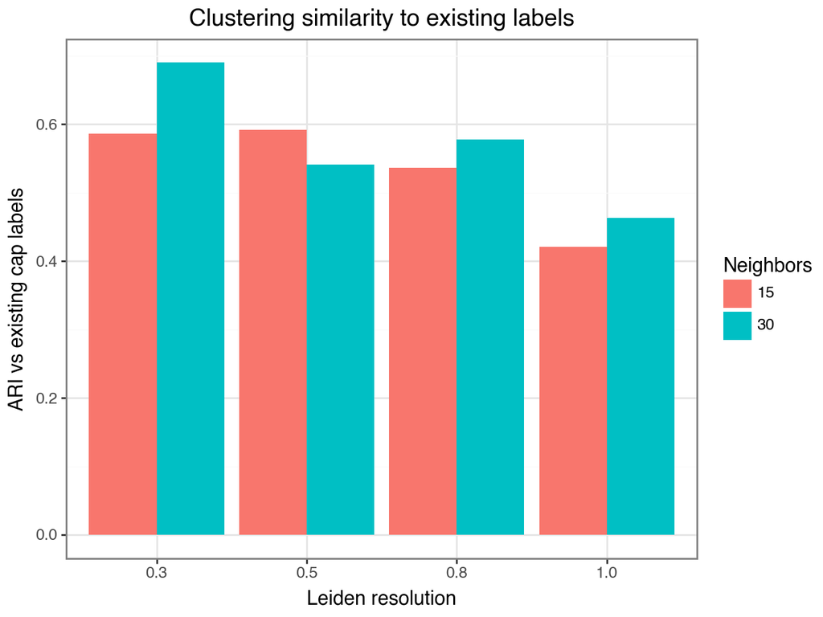

```python
#plotting ARI
(ggplot(
        sensitivity_results,
        aes(x="factor(resolution)", y="ARI_vs_cap", fill="factor(n_neighbors)")
    )
    + geom_col(position="dodge")
    + labs(
        x="Leiden resolution",
        y="ARI vs existing cap labels",
        fill="Neighbors",
        title="Clustering similarity to existing labels"
    )
    + theme_bw())
```

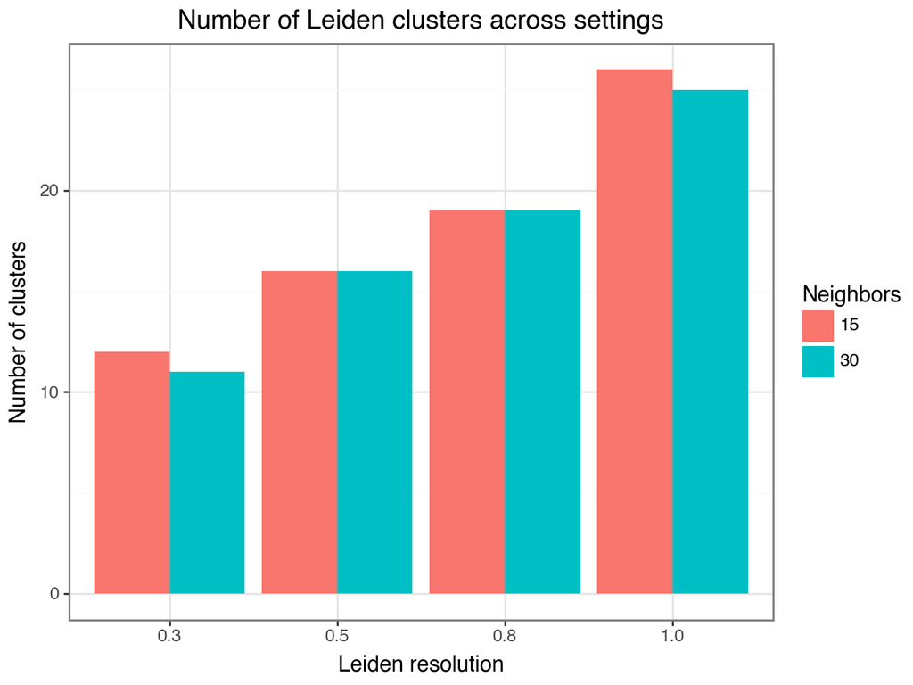

```python
#plotting num of clusters
(ggplot(
        sensitivity_results,
        aes(x="factor(resolution)", y="n_clusters", fill="factor(n_neighbors)")
    )
    + geom_col(position="dodge")
    + labs(
        x="Leiden resolution",
        y="Number of clusters",
        fill="Neighbors",
        title="Number of Leiden clusters across settings"
    )
    + theme_bw())
```

Increasing the Leiden resolution increases the number of clusters, as expected. The similarity to the existing `cap` labels is moderate across settings: the clustering recovers part of the published annotation structure, but it does not reproduce it exactly.

The highest similarity is observed with a lower-resolution setting (`n_neighbors = 30`, `resolution = 0.3`). At higher resolution, Leiden produces more clusters and the match to the existing labels decreases, which suggests that finer clustering begins to split published labels into smaller groups.

NMI remains around 0.68–0.74, again suggesting partial but not exact agreement between simple clustering and the existing labels.

Overall, this check supports a cautious use of clustering. A simple Leiden workflow on the stored scVI embedding captures several major endothelial groups, but the exact cluster boundaries depend on parameter choices. For this reason, I keep the published annotations as the main reference and use clustering only as a secondary check.

## Notes from this analysis

This is a small analysis on a processed object, so I do not use it to claim new endothelial states or subpopulations.

The existing labels are understandable from the data. Arterial, venous, capillary, and some tissue-associated labels show up in the UMAPs, in the marker plot, and in the organ-label heatmap.

The organ-label heatmap was the most useful summary for me. It shows the difference between broad labels such as `art_ec`, `ven_ec`, and `cap_ec`, and labels that are mostly tied to one organ or tissue type, such as `blood_brain_barrier_ec`, `glomeruli_ec`, `aerocyte_ec`, and liver capillary labels.

The clustering check also helped. A simple Leiden clustering recovers part of the existing annotation structure, but the result changes when resolution and neighborhood size change. So I keep the published labels as the reference and use clustering only as a check.